# report

М. М. Шамшиев

317 группа

13.03.2018

### Аннотация

В данном отчете приведены основные результаты, полученные в ходе выполнения практического задания "Свёрточные автокодировщики для улучшения качества классификации". Была написана собственная реализация свёрточного автокодировщика с произвольным количеством слоев и реализация сверточной сети.  
Также был проведен ряд экспериментов, включающих в себя подбор оптимальных параметров сверточной сети для решения задачи классификации датасета STL-10, а также исследован вопрос улучшения качества классификации с помощью неразмеченных данных (в частности, с использованием сверточных автокодировщиков).

Замечание: при выборе спецификации классов было принято решение написать единый класс $ConvNetAutoEncoder$, реализующий как сверточный автокодировщик, так и сверточную нейронную сеть. В зависимости от значения булевого параметра $autoencoder$ метода $forward$ данного класса, входной объект подаётся на соответствующие слои сети.

```python
import torch
import numpy as np
from torch.autograd import Variable
import torch.nn as nn
import torch.nn.functional as F
from math import floor
import torchvision
import torchvision.transforms as transforms
import torch.utils

import torch.optim as optim
import matplotlib.pyplot as plt
from sklearn.ensemble import RandomForestClassifier
import time
import gc

from task1 import ConvNetAutoEncoder
from task1 import fit_autoencoder
from task1 import fit_net
from task1 import check_accuracy
from task1 import batch

%matplotlib inline
```

```python
transform = transforms.Compose(
    [transforms.Resize((32, 32), 2),
     transforms.ToTensor(),
     transforms.Normalize((0.5, 0.5, 0.5), (0.5, 0.5, 0.5))])
```

```python
trainset = torchvision.datasets.STL10(root='.', split='train', download=False, transform=transform)
trainloader = torch.utils.data.DataLoader(trainset, batch_size=4,
                                          shuffle=True, num_workers=2)
testset = torchvision.datasets.STL10(root='.', split='test', download=False, transform=transform)
testloader = torch.utils.data.DataLoader(testset, batch_size=4,
                                         shuffle=False, num_workers=2)
```

```python
def imshow(img):
    img = img / 2 + 0.5
    npimg = img.numpy()
    plt.imshow(np.transpose(npimg, (1, 2, 0)))
```

## Эксперимент 1. Получение бейзлайна качества на моделях логистической регрессии и случайного леса

### Модель логистической регрессии

Реализуем модель мультиномиальной логистической регрессии как однослойную нейронную сеть и проведем обучение методом стохастического градиентного спуска с шагом $0.001$ и коэффициентом l2-регуляризации равным $0.01$. Количество эпох было взято равным $30$.

В процессе обучения в качестве отладочной информации каждые 5 эпох будем выводить значение оптимизируемого функционала.

```python
net = ConvNetAutoEncoder(input_size=(3, 32, 32), layers_num=0)
```

```python
criterion = nn.CrossEntropyLoss()
optimizer = optim.SGD(net.parameters(), lr=0.001, weight_decay=0.01)
```

```python
fit_net(net, optimizer, criterion, trainloader, 30)
```

```
[epoch 5] loss: 1.783
[epoch 10] loss: 1.625
[epoch 15] loss: 1.555
[epoch 20] loss: 1.507
[epoch 25] loss: 1.471
[epoch 30] loss: 1.441
```

```
1.4413507766723632
```

```python
check_accuracy(net, testloader)
```

```
Accuracy of the network: 36.77 %
```

```
36.775
```

## Случайный лес

Предварительно преобразовав обучающую и тестовую выборку к типу numpy array, обучим классификатор, соответствующий модели случайного леса с количеством деревьев, равным $300$. Остальные параметры модели оставим равными значениям по умолчанию.

```python
cls = RandomForestClassifier(n_estimators=300)
```

```python
fulltrainloader = torch.utils.data.DataLoader(trainset, batch_size=len(trainset),
                                          shuffle=True, num_workers=2)
dataiter = iter(fulltrainloader)
images, labels = dataiter.next()
train = images.numpy()
train = train.reshape((5000, 3 * 32 * 32))
y_train = labels.numpy()
```

```python
cls.fit(train, y_train)
```

```
RandomForestClassifier(bootstrap=True, class_weight=None, criterion='gini',
            max_depth=None, max_features='auto', max_leaf_nodes=None,
            min_impurity_decrease=0.0, min_impurity_split=None,
            min_samples_leaf=1, min_samples_split=2,
            min_weight_fraction_leaf=0.0, n_estimators=300, n_jobs=1,
            oob_score=False, random_state=None, verbose=0,
            warm_start=False)
```

```python
fulltestloader = torch.utils.data.DataLoader(testset, batch_size=len(testset),
                                          shuffle=True, num_workers=2)
dataiter = iter(fulltestloader)
images, labels = dataiter.next()
test = images.numpy()
test = test.reshape((8000, 3 * 32 * 32))
y_test = labels.numpy()
```

```python
predicted = cls.predict(test)
print('Accuracy of the random forest classifier: %.2f %%' % (100 * (predicted == y_test).sum() / len(y_test)))
```

```
Accuracy of the random forest classifier: 43.08 %
```

Таким образом, в качестве бейзлайнов взяты следующие значения точностей моделей:  
LogReg: 36.77%  
RandomForest: 43.08%

Одной из основных целей дальнейших экспериментов будет улучшение качества классификации с помощью неразмеченных данных.

## Эксперимент 2. Исследование влияния различных параметров сверточной сети на качество и скорость её работы

В качестве модели для эксперимента была взята однослойная (1 сверточный слой, 1 pooling слой, 1 полносвязный слой) сверточная сеть. Для ускорения процесса перебора значений различных параметров будем производить обучение метододом стохастического градиентного спуска на $10$ эпохах, а финальную модель обучим, как и ранее, на $30$ эпохах, чтобы иметь возможность сравнивать качество с полученными ранее бейзлайнами.

```python
criterion = nn.CrossEntropyLoss()
```

### 1. Размер ядра свёртки

```python
losses = []
accuracies = []
times = []
filt_sizes = range(2, 9)
trainloader = torch.utils.data.DataLoader(trainset, batch_size=4, shuffle=True, num_workers=2)
testloader = torch.utils.data.DataLoader(testset, batch_size=4, shuffle=True, num_workers=2)
for size in filt_sizes:
    net = ConvNetAutoEncoder(input_size=(3, 32, 32), layers_num=1, conv_out_channels=2, conv_kernel_size=size,
                             conv_stride=2, pool_kernel_size=2, pool_stride=1)
    optimizer = optim.SGD(net.parameters(), lr=0.01, weight_decay=0.01)
    print("Размер фильтра = %d:" % size)
    start = time.clock()
    losses.append(fit_net(net, optimizer, criterion, trainloader, 10))
    times.append(time.clock() - start)
    accuracies.append(check_accuracy(net, testloader))
```

```
Размер фильтра = 2:
[epoch 5] loss: 1.773
[epoch 10] loss: 1.559
Accuracy of the network: 39.24 %
Размер фильтра = 3:
[epoch 5] loss: 1.691
[epoch 10] loss: 1.464
Accuracy of the network: 40.56 %
Размер фильтра = 4:
[epoch 5] loss: 1.649
[epoch 10] loss: 1.452
Accuracy of the network: 40.79 %
Размер фильтра = 5:
[epoch 5] loss: 1.743
[epoch 10] loss: 1.543
Accuracy of the network: 39.56 %
Размер фильтра = 6:
[epoch 5] loss: 1.708
[epoch 10] loss: 1.583
Accuracy of the network: 39.29 %
Размер фильтра = 7:
[epoch 5] loss: 1.705
[epoch 10] loss: 1.556
Accuracy of the network: 38.36 %
Размер фильтра = 8:
[epoch 5] loss: 1.723
[epoch 10] loss: 1.580
Accuracy of the network: 37.88 %
```

```python
losses_1 = losses
accuracies_1 = accuracies
times_1 = times
```

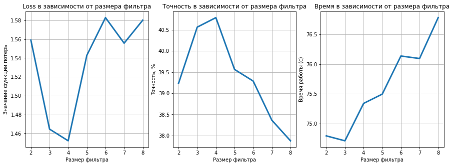

```python
fig, (ax1, ax2, ax3) = plt.subplots(1, 3, figsize=(15, 5))
ax1.plot(range(2, 9), losses_1, lw=3)
ax1.set_title("Loss в зависимости от размера фильтра")
ax1.set_xlabel("Размер фильтра")
ax1.set_ylabel("Значение функции потерь")
ax1.grid()

ax2.plot(range(2, 9), accuracies_1, lw=3)
ax2.set_title("Точность в зависимости от размера фильтра")
ax2.set_xlabel("Размер фильтра")
ax2.set_ylabel("Точность, %")
ax2.grid()

ax3.plot(range(2, 9), times_1, lw=3)
ax3.set_title("Время в зависимости от размера фильтра")
ax3.set_xlabel("Размер фильтра")
ax3.set_ylabel("Время работы (с)")
ax3.grid()
```

Судя по графикам, оптимальным значением данного параметра является размер фильтра равный $4$. Как можно заметить, на этом значении достигается как минимум значения функции потерь, так и наилучшая точность на тестовой выборке.

C увеличением размера фильтра качество классификации (как значение функции потерь, так и точность) значительно ухудшается. Возможно это связано с тем, что при рассмотрении окрестностей большого радиуса пикселя исходной картинки в результирующий пиксель попадает слишком много, в какой-то степени, "шумовой" информации, которая способствует ухудшению качества классификации.

Также, ожидаемо, модели с бо́льшим значением данного параметра затрачивали бо́льшее время на обучение, поскольку с увеличением размера фильтра увеличивается и количество алгебраических операций, которые необходимо произвести.

### 2. Количество фильтров на сверточном слое

```python
losses = []
accuracies = []
times = []
num_filt = range(5, 45, 5)
for num in num_filt:
    net = ConvNetAutoEncoder(input_size=(3, 32, 32), layers_num=1, conv_out_channels=num, conv_kernel_size=4,
                             conv_stride=2, pool_kernel_size=2, pool_stride=1)
    optimizer = optim.SGD(net.parameters(), lr=0.01, weight_decay=0.01)
    print("Количество фильтров = %d:" % num)
    start = time.clock()
    losses.append(fit_net(net, optimizer, criterion, trainloader, 10))
    times.append(time.clock() - start)
    accuracies.append(check_accuracy(net, testloader))
```

```
Количество фильтров = 5:
[epoch 5] loss: 1.513
[epoch 10] loss: 1.241
Accuracy of the network: 46.76 %
Количество фильтров = 10:
[epoch 5] loss: 1.440
[epoch 10] loss: 1.123
Accuracy of the network: 48.61 %
Количество фильтров = 15:
[epoch 5] loss: 1.406
[epoch 10] loss: 1.033
Accuracy of the network: 48.70 %
Количество фильтров = 20:
[epoch 5] loss: 1.379
[epoch 10] loss: 1.036
Accuracy of the network: 49.38 %
Количество фильтров = 25:
[epoch 5] loss: 1.371
[epoch 10] loss: 1.010
Accuracy of the network: 49.66 %
Количество фильтров = 30:
[epoch 5] loss: 1.361
[epoch 10] loss: 0.986
Accuracy of the network: 48.89 %
Количество фильтров = 35:
[epoch 5] loss: 1.348
[epoch 10] loss: 0.972
Accuracy of the network: 51.23 %
Количество фильтров = 40:
[epoch 5] loss: 1.353
[epoch 10] loss: 0.961
Accuracy of the network: 50.83 %
```

```python
losses_2 = losses
accuracies_2 = accuracies
times_2 = times
```

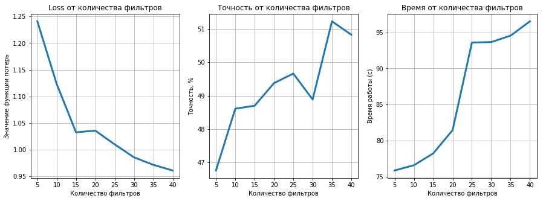

```python
fig, (ax1, ax2, ax3) = plt.subplots(1, 3, figsize=(15, 5))
ax1.plot(range(5, 45, 5), losses_2, lw=3)
ax1.set_title("Loss от количества фильтров")
ax1.set_xlabel("Количество фильтров")
ax1.set_ylabel("Значение функции потерь")
ax1.grid()

ax2.plot(range(5, 45, 5), accuracies_2, lw=3)
ax2.set_title("Точность от количества фильтров")
ax2.set_xlabel("Количество фильтров")
ax2.set_ylabel("Точность, %")
ax2.grid()

ax3.plot(range(5, 45, 5), times_2, lw=3)
ax3.set_title("Время от количества фильтров")
ax3.set_xlabel("Количество фильтров")
ax3.set_ylabel("Время работы (с)")
ax3.grid()
```

Как видно из приведенных графиков, с увеличением количества фильтров значение оптимизируемого функционала падает практически монотонно. В то же время точность классификации также увеличивается. Иными словами, при увеличении сложности модели она продолжает показывать лучшие результаты на тестовой выборке, а это значит, что модель не переобучается.

С другой стороны, с увеличением значения данного параметра время работы моделей заметно возрастает. Нетрудно понять, что это происходит в связи с увеличением количества параметров сети, значения которых необходимо подбирать в процессе обучения.

Выбирая оптимальное значение количества фильтров на сверточном слое для финальной модели, было принято решение сделать акцент на точности модели, нежели на балансе точности и времени работы, поскольку, всё же, разница во времени обучения разных моделей порядка пары минут не столь существена. Итак, параметр количества фильтров было решено взять равным $35$.

### 3. Количество свёрточных блоков

В данном эксперементе было необходимо провести исследование влияния количества сверточных блоков сети на качество и скорость обучения модели. Для всех слоев, начиная со 2го, было принято решение установить параметр количества фильтров равным $15$ (исходя из соображений баланса качества и времени работы), а параметр stride равным $1$, поскольку иначе уже на 3ем слое преобразованное изображение получалось бы малых размеров (при данных параметрах 5х5) и качество предсказаний значительно ухудшалось.

```python
losses = []
accuracies = []
times = []
num_layers = range(1, 4)
for num in num_layers:
    net = ConvNetAutoEncoder(input_size=(3, 32, 32), layers_num=num, conv_out_channels=[35] + [15] * (num - 1), conv_kernel_size=4,
                             conv_stride=[2] + [1] * (num - 1), pool_kernel_size=2, pool_stride=1)
    optimizer = optim.SGD(net.parameters(), lr=0.01, weight_decay=0.01)
    start = time.clock()
    losses.append(fit_net(net, optimizer, criterion, trainloader, 10))
    times.append(time.clock() - start)
    accuracies.append(check_accuracy(net, testloader))
```

```
[epoch 5] loss: 1.351
[epoch 10] loss: 0.962
Accuracy of the network: 50.39 %
[epoch 5] loss: 1.498
[epoch 10] loss: 1.217
Accuracy of the network: 47.34 %
[epoch 5] loss: 1.602
[epoch 10] loss: 1.367
Accuracy of the network: 46.65 %
```

Полученные результаты свидетельствуют о том, что с увеличением количества сверточных блоков качество предсказания ухудшалось. Таким образом, в качестве наилучшей архитектуры сверточной сети для решения данной задачи возьмём один сверточный блок + полносвязный слой.

```python
times
```

```
[99.99842195678502, 121.39479220078647, 127.79258738788485]
```

Как и следовало ожидать, время обучения модели значительно увеличивалось с ростом количества свёрточных блоков, что также легко объясняется увеличением количества параметров, которые нужно подобрать.

### Momentum

```python
losses = []
accuracies = []
times = []
momentums = [0.1, 0.2, 0.3, 0.4, 0.5]
for momentum in momentums:
    net = ConvNetAutoEncoder(input_size=(3, 32, 32), layers_num=1, conv_out_channels=35, conv_kernel_size=4,
                             conv_stride=2, pool_kernel_size=2, pool_stride=1)
    optimizer = optim.SGD(net.parameters(), lr=0.01, weight_decay=0.01, momentum=momentum)
    start = time.clock()
    losses.append(fit_net(net, optimizer, criterion, trainloader, 10))
    times.append(time.clock() - start)
    accuracies.append(check_accuracy(net, testloader))
```

```
[epoch 5] loss: 1.363
[epoch 10] loss: 0.978
Accuracy of the network: 48.99 %
[epoch 5] loss: 1.350
[epoch 10] loss: 0.974
Accuracy of the network: 50.29 %
[epoch 5] loss: 1.355
[epoch 10] loss: 0.974
Accuracy of the network: 48.26 %
[epoch 5] loss: 1.365
[epoch 10] loss: 0.995
Accuracy of the network: 49.35 %
[epoch 5] loss: 1.398
[epoch 10] loss: 1.035
Accuracy of the network: 46.49 %
```

Как видно из полученных результатов, на значениях параметра равных $0.1, 0.2, 0.3$, значения оптимизируемого функционала практически одинаковы.  
Но стоит заметить, что точность модели, соответсвующая параметру $momentum = 0.2$ выше, нежели у других моделей. Таким образом, различным значениям параметров модели соответсвуют сравнимые значения оптимизируемого функционала, но, видимо, параметры, полученные при $momentum = 0.2$, лучше подходят для решения данной задачи.

### Финальная модель

```python
net = ConvNetAutoEncoder(input_size=(3, 32, 32), layers_num=1, conv_out_channels=35, conv_kernel_size=4, conv_stride=2,
                         pool_kernel_size=2, pool_stride=1)
```

```python
optimizer = optim.SGD(net.parameters(), lr=0.01, weight_decay=0.01, momentum=0.2)
```

```python
fit_net(net, optimizer, criterion, trainloader, 30)
```

```
[epoch 5] loss: 1.357
[epoch 10] loss: 0.976
[epoch 15] loss: 0.800
[epoch 20] loss: 0.706
[epoch 25] loss: 0.666
[epoch 30] loss: 0.640
```

```
0.6399236728131771
```

```python
check_accuracy(net, testloader)
```

```
Accuracy of the network: 50.80 %
```

```
50.8
```

Итак, подбирая оптимальные значения различных параметров свёрточной сети удалось достичь точности $50.8$%.

## Эксперимент 3

Для того, чтобы в дальнейшем иметь возможность корректно проинициализировать параметры сверточной сети из предыдущего пункта, зададим значения параметров количества фильтров на сверточном слое и размеры фильтров такими же, как и у модели сверточной сети.  
При этом в связи с тем, что количество фильтров на сверточном слое было решено взять равным $35$, размерность выхода энкодера сильно превышает размерность исходной картинки.

Конечно, предпочтительней было бы, если кодировщик переводил исходное признаковое простраство в пространство меньшей размерности. Но поскольку в данном задании главная цель - это повышение качества классификации с помощью неразмеченных данных, то такие значения параметров кажутся допустимыми.

```python
unlabeledset = torchvision.datasets.STL10(root='.', split='unlabeled', download=False, transform=transform)
```

```python
AutoEncoder = ConvNetAutoEncoder(input_size=(3, 32, 32), layers_num=1, conv_out_channels=35, conv_kernel_size=4, conv_stride=1,
                                 conv_padding=2, pool_kernel_size=2, pool_stride=1)
```

```python
criterion = nn.MSELoss()
optimizer = optim.SGD(AutoEncoder.parameters(), lr=0.01, weight_decay=0.01)
```

```python
fit_autoencoder(AutoEncoder, optimizer, criterion, unlabeledset, 1, 4)
```

```
[1,  5000] loss: 0.018
[1, 10000] loss: 0.012
[1, 15000] loss: 0.012
[1, 20000] loss: 0.012
[1, 25000] loss: 0.012
```

```
0.012210407600272448
```

Как видно, значения параметров $stride = 1$ и $padding = 2$ позволяют достигнуть довольно низкого значения MSE. Провизуализируем несколько картинок до применения к ним автокодировщика:

```python
images = batch(testset, 4, 0)
imshow(torchvision.utils.make_grid(images))
```

[output not shown]

И после:

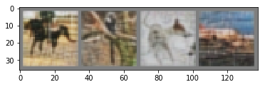

```python
images = AutoEncoder(Variable(batch(testset, 4, 0)), autoencoder=True)
imshow(torchvision.utils.make_grid(images.data))
```

## Эксперимент 4

В данном эксперименте было необходимо исследовать, улучшится ли качество классификации моделей из первого эксперимента, если вместо исходных изображений использовать признаки, выделенные с помощью автокодировщика.  
Для чистоты эксперимента обучение моделей производилось точно также, как и ранее, разве что на вход моделям подавался выход энкодера.

### Модель логистической регрессии

```python
image = batch(testset, 1, 0)
image = AutoEncoder.encode(Variable(image))
encoded_size = image.size()
```

```python
LogReg = ConvNetAutoEncoder(input_size=encoded_size[1:], layers_num=0)
```

```python
criterion = nn.CrossEntropyLoss()
optimizer = optim.SGD(LogReg.parameters(), lr=0.001, weight_decay=0.01)
```

```python
running_loss = 0.0
last_loss = 0.0
for epoch in range(30):
    for i, data in enumerate(trainloader, 0):
        inputs, labels = data
        inputs, labels = Variable(inputs), Variable(labels)
        inputs = AutoEncoder.encode(inputs)
        optimizer.zero_grad()

        outputs = LogReg(inputs)
        loss = criterion(outputs, labels)
        loss.backward()
        optimizer.step()
        running_loss += loss.data[0]
    if epoch % 5 == 4:
        print('[epoch %d] loss: %.3f' % (epoch + 1, running_loss / (5 * len(trainloader))))
        last_loss = running_loss / (5 * len(trainloader))
        running_loss = 0.0
```

```
[epoch 5] loss: 1.659
[epoch 10] loss: 1.422
[epoch 15] loss: 1.322
[epoch 20] loss: 1.257
[epoch 25] loss: 1.210
[epoch 30] loss: 1.171
```

```python
correct = 0
total = 0
for data in testloader:
    inputs, labels = data
    inputs = Variable(inputs)
    inputs = AutoEncoder.encode(inputs)
    outputs = LogReg(inputs)
    _, predicted = torch.max(outputs.data, 1)
    total += labels.size(0)
    correct += (predicted == labels).sum()
print('Accuracy of the network: %.2f %%' % (100 * correct / total))
```

```
Accuracy of the network: 45.79 %
```

Итак, точность модели логистической регрессии, обученной на признаках, выделенных с помощью автоэнкодера, увеличилась на $9.02$%.  
Такое значительное увеличение точности модели логистической регрессии можно связать с тем, что, подавая ей на вход выход энкодера, мы в какой-то степени исскуственно добавили к данной сети один сверточный блок, которая ранее состояла лишь из одного полносвязного слоя.  
Таким образом, в итоге получилась некая сверточная сеть, а, как мы могли убедиться ранее, сверточные сети гораздо лучше справляются с данной задачей классификации, нежели линейные модели.

### Случайный лес

```python
cls = RandomForestClassifier(n_estimators=300)
```

```python
fulltrainloader = torch.utils.data.DataLoader(trainset, batch_size=len(trainset), shuffle=True, num_workers=2)
dataiter = iter(fulltrainloader)
images, labels = dataiter.next()
train_encoded = AutoEncoder.encode(Variable(images))
train_encoded = train_encoded.data.numpy()
train_encoded = train_encoded.reshape((5000, 35 * 32 * 32))
```

```python
cls.fit(train_encoded, labels.numpy())
```

```
RandomForestClassifier(bootstrap=True, class_weight=None, criterion='gini',
            max_depth=None, max_features='auto', max_leaf_nodes=None,
            min_impurity_decrease=0.0, min_impurity_split=None,
            min_samples_leaf=1, min_samples_split=2,
            min_weight_fraction_leaf=0.0, n_estimators=300, n_jobs=1,
            oob_score=False, random_state=None, verbose=0,
            warm_start=False)
```

```python
fulltestloader = torch.utils.data.DataLoader(testset, batch_size=len(testset), shuffle=False, num_workers=2)
dataiter = iter(fulltestloader)
images, labels = dataiter.next()
test_encoded = AutoEncoder.encode(Variable(images))
test_encoded = test_encoded.data.numpy()
test_encoded = test_encoded.reshape((8000, 35 * 32 * 32))
```

```python
predicted = cls.predict(test_encoded)
print('Accuracy of the random forest classifier: %.2f %%' % (100 * (predicted == labels.numpy()).sum() / len(labels.numpy())))
```

```
Accuracy of the random forest classifier: 44.96 %
```

Точность модели случайного леса, обученной на признаках, выделенных с помощью автоэнкодера, увеличилась на $1.88$%.

Таким образом, неразмеченные данные помогли улучшить качество классификации модели логистической регрессии и случайного леса: с помощью обученного на них автокодировщика удалось сгенерировать новое признаковое пространство, в котором обе модели показали лучшие результаты.

Тем не менее, показатели точности моделей логистической регрессии и случайного до сих пор значительно устапают точности нейросетевой модели из эксперимента 2.

## Эксперимент 5

Целью данного эксперимента было улучшение качества классификации сверточной нейронной сети с помощью инициализации весов первых слоев весами обученного ранее автокодировщика.  
В качестве эксперементальной модели была взята свёрточная нейронная сеть с двумя сверточными блоками, параметры первого из которых (количество фильтров, размер ядра свертки, stride и padding) полностью совпадали с параметрами сверточного блока автокодировщика. Далее параметры (веса) данного блока инициализировались с помощью весов сверточного слоя энкодера.  
Второй сверточный блок был взят со следующими параметрами: количество фильтров = 15, stride = 2, размер ядра = 4 и padding = 2.

Далее данная модель обучалась на тренировочной выборке методом стохастического градиентного спуска с такими же параметрами, что и ранее, за одним исключением: обучение производилось на меньшем количестве эпох. Это обусловлено тем, что во время выполнения эксперимента было замечено явление переобучения: обучив описанную выше сеть на 30 эпохах, оптимизируемый функционал принимал значения, в два раза меньшие, чем во втором эксперементе (порядка 0.3), но точность на тестовой выборки заметно падала (составляла около 46%).

```python
net = ConvNetAutoEncoder(input_size=(3, 32, 32), layers_num=2, conv_out_channels=(35, 15), conv_kernel_size=4,
                         conv_stride=(1, 2), conv_padding=2, pool_kernel_size=2, pool_stride=1)
```

```python
net.conv[0] = AutoEncoder.conv[0]
```

```python
criterion = nn.CrossEntropyLoss()
optimizer = optim.SGD(net.parameters(), lr=0.01, weight_decay=0.01, momentum=0.2)
```

```python
fit_net(net, optimizer, criterion, trainloader, 10)
```

```
[epoch 5] loss: 1.250
[epoch 10] loss: 0.748
```

```
0.7475542591390759
```

```python
check_accuracy(net, testloader)
```

```
Accuracy of the network: 52.17 %
```

```
52.175
```

Итак, проиниализировав веса первого слоя двуслойной сверточной сети, удалось улучшить качество модели из 2 эксперимента на 1.375%.

## Заключение

Таким образом, в ходе выполнения практического задания "Свёрточные автокодировщики для улучшения качества классификации" была написано собственная реализация свёрточной нейронной сети и свёртночного автокодировщика.  
Также были произведен подбор оптимальных параметров для решения задачи классификации датасете STL-10.  
Помимо этого, с помощью обучения автокодировщика на неразмеченных данных удалось увеличить точность классификации моделей логистической регрессии, случайного леса и свёрточной нейронной сети. Наивысшую точность в 52.17% показала модель двуслойной сверточной нейронной сети, веса первого сверточного слоя которой были проинициализированы весами автокодировщика.

## Бонус 1

Целью данного эксперимента было исследование вопроса улучшения качества автокодировщика при использовании нескольких свёрточных блоков (в частности, двух). Ниже приведены 2 лучшие модели двуслойных автокодировщиков.

```python
AutoEncoder = ConvNetAutoEncoder(input_size=(3, 32, 32), layers_num=2, conv_out_channels=15, conv_kernel_size=4,
                                 conv_stride=1, conv_padding=2, pool_kernel_size=2, pool_stride=1)
```

```python
criterion = nn.MSELoss()
optimizer = optim.SGD(AutoEncoder.parameters(), lr=0.01, weight_decay=0.01)
```

```python
fit_autoencoder(AutoEncoder, optimizer, criterion, unlabeledset, 1, 4)
```

```
[1,  5000] loss: 0.035
[1, 10000] loss: 0.022
[1, 15000] loss: 0.021
[1, 20000] loss: 0.021
[1, 25000] loss: 0.021
```

```
0.020626147472672163
```

```python
images = batch(testset, 4, 0)
imshow(torchvision.utils.make_grid(images))
```

[output not shown]

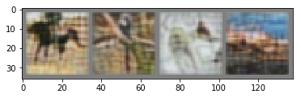

```python
images = AutoEncoder(Variable(batch(testset, 4, 0)), autoencoder=True)
imshow(torchvision.utils.make_grid(images.data))
```

```python
AutoEncoder = ConvNetAutoEncoder(input_size=(3, 32, 32), layers_num=2, conv_out_channels=(25, 10), conv_kernel_size=4,
                                 conv_stride=1, conv_padding=2, pool_kernel_size=2, pool_stride=1)
```

```python
criterion = nn.MSELoss()
optimizer = optim.SGD(AutoEncoder.parameters(), lr=0.01, weight_decay=0.01)
```

```python
fit_autoencoder(AutoEncoder, optimizer, criterion, unlabeledset, 1, 4)
```

```
[1,  5000] loss: 0.032
[1, 10000] loss: 0.019
[1, 15000] loss: 0.017
[1, 20000] loss: 0.018
[1, 25000] loss: 0.018
```

```
0.01803504591966048
```

```python
images = batch(testset, 4, 0)
imshow(torchvision.utils.make_grid(images))
```

[output not shown]

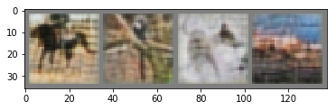

```python
images = AutoEncoder(Variable(batch(testset, 4, 0)), autoencoder=True)
imshow(torchvision.utils.make_grid(images.data))
```

Визуально результаты работы данных автокодировщиков почти не отличаются от результатов работы однослойной модели из 3го эксперимента. Но достичь такого же низкого значения MSE при тех же параметрах обучения, как в 3ем эксперименте, не удалось. Также данные модели уступают во времени работы автокодировщику с одним слоем.  
С другой стороны, как достоинство можно отметить, что размерность выхода энкодера двуслойных моделей гораздо меньше, чем соответсвующая размерность выхода однослойного энкодера.